# Risk Factor Analysis

## Outcome Variable

**Outcome Variable:** pers_wasted624

## Predictor Variables

**Intervention Variable:** ever_swasted06

**Adjustment Set:**

- sex
- arm
- enstunt
- month
- brthmon
- vagbrth
- single
- W_gagebrth
- W_birthwt
- W_birthlen
- W_mage
- W_mhtcm
- W_meducyrs
- W_feducyrs
- W_parity
- delta_month
- delta_brthmon
- delta_vagbrth
- delta_single
- delta_W_gagebrth
- delta_W_birthwt
- delta_W_birthlen
- delta_W_mage
- delta_W_mhtcm
- delta_W_meducyrs
- delta_W_feducyrs
- delta_W_parity

## Stratifying Variables

The analysis was stratified on these variable(s):

- studyid
- country

## Data Summary

| studyid | country | ever_swasted06 | pers_wasted624 | n_cell | n |
| --- | --- | --- | --- | --- | --- |
| ki0047075b-MAL-ED | BANGLADESH | 0 | 0 | 210 | 240 |
| ki0047075b-MAL-ED | BANGLADESH | 0 | 1 | 14 | 240 |
| ki0047075b-MAL-ED | BANGLADESH | 1 | 0 | 12 | 240 |
| ki0047075b-MAL-ED | BANGLADESH | 1 | 1 | 4 | 240 |
| ki0047075b-MAL-ED | BRAZIL | 0 | 0 | 203 | 207 |
| ki0047075b-MAL-ED | BRAZIL | 0 | 1 | 2 | 207 |
| ki0047075b-MAL-ED | BRAZIL | 1 | 0 | 2 | 207 |
| ki0047075b-MAL-ED | BRAZIL | 1 | 1 | 0 | 207 |
| ki0047075b-MAL-ED | INDIA | 0 | 0 | 198 | 235 |
| ki0047075b-MAL-ED | INDIA | 0 | 1 | 17 | 235 |
| ki0047075b-MAL-ED | INDIA | 1 | 0 | 9 | 235 |
| ki0047075b-MAL-ED | INDIA | 1 | 1 | 11 | 235 |
| ki0047075b-MAL-ED | NEPAL | 0 | 0 | 227 | 235 |
| ki0047075b-MAL-ED | NEPAL | 0 | 1 | 1 | 235 |
| ki0047075b-MAL-ED | NEPAL | 1 | 0 | 6 | 235 |
| ki0047075b-MAL-ED | NEPAL | 1 | 1 | 1 | 235 |
| ki0047075b-MAL-ED | PERU | 0 | 0 | 267 | 270 |
| ki0047075b-MAL-ED | PERU | 0 | 1 | 2 | 270 |
| ki0047075b-MAL-ED | PERU | 1 | 0 | 1 | 270 |
| ki0047075b-MAL-ED | PERU | 1 | 1 | 0 | 270 |
| ki0047075b-MAL-ED | SOUTH AFRICA | 0 | 0 | 252 | 259 |
| ki0047075b-MAL-ED | SOUTH AFRICA | 0 | 1 | 1 | 259 |
| ki0047075b-MAL-ED | SOUTH AFRICA | 1 | 0 | 5 | 259 |
| ki0047075b-MAL-ED | SOUTH AFRICA | 1 | 1 | 1 | 259 |
| ki0047075b-MAL-ED | TANZANIA, UNITED REPUBLIC OF | 0 | 0 | 241 | 245 |
| ki0047075b-MAL-ED | TANZANIA, UNITED REPUBLIC OF | 0 | 1 | 0 | 245 |
| ki0047075b-MAL-ED | TANZANIA, UNITED REPUBLIC OF | 1 | 0 | 4 | 245 |
| ki0047075b-MAL-ED | TANZANIA, UNITED REPUBLIC OF | 1 | 1 | 0 | 245 |
| ki1000108-CMC-V-BCS-2002 | INDIA | 0 | 0 | 284 | 370 |
| ki1000108-CMC-V-BCS-2002 | INDIA | 0 | 1 | 14 | 370 |

[output cut: 102 more lines]

The following strata were considered:

- studyid: ki0047075b-MAL-ED, country: BANGLADESH
- studyid: ki0047075b-MAL-ED, country: BRAZIL
- studyid: ki0047075b-MAL-ED, country: INDIA
- studyid: ki0047075b-MAL-ED, country: NEPAL
- studyid: ki0047075b-MAL-ED, country: PERU
- studyid: ki0047075b-MAL-ED, country: SOUTH AFRICA
- studyid: ki0047075b-MAL-ED, country: TANZANIA, UNITED REPUBLIC OF
- studyid: ki1000108-CMC-V-BCS-2002, country: INDIA
- studyid: ki1000108-IRC, country: INDIA
- studyid: ki1000109-EE, country: PAKISTAN
- studyid: ki1000109-ResPak, country: PAKISTAN
- studyid: ki1000304b-SAS-CompFeed, country: INDIA
- studyid: ki1000304b-SAS-FoodSuppl, country: INDIA
- studyid: ki1017093-NIH-Birth, country: BANGLADESH
- studyid: ki1017093b-PROVIDE, country: BANGLADESH
- studyid: ki1017093c-NIH-Crypto, country: BANGLADESH
- studyid: ki1066203-TanzaniaChild2, country: TANZANIA, UNITED REPUBLIC OF
- studyid: ki1101329-Keneba, country: GAMBIA
- studyid: ki1112895-Guatemala BSC, country: GUATEMALA
- studyid: ki1113344-GMS-Nepal, country: NEPAL
- studyid: ki1114097-CMIN, country: BANGLADESH
- studyid: ki1114097-CMIN, country: BRAZIL
- studyid: ki1114097-CMIN, country: GUINEA-BISSAU
- studyid: ki1114097-CMIN, country: PERU
- studyid: ki1114097-CONTENT, country: PERU
- studyid: ki1119695-PROBIT, country: BELARUS
- studyid: ki1126311-ZVITAMBO, country: ZIMBABWE
- studyid: ki1135781-COHORTS, country: GUATEMALA
- studyid: ki1135781-COHORTS, country: INDIA
- studyid: ki1135781-COHORTS, country: PHILIPPINES
- studyid: ki1148112-LCNI-5, country: MALAWI
- studyid: kiGH5241-JiVitA-3, country: BANGLADESH
- studyid: kiGH5241-JiVitA-4, country: BANGLADESH

### Dropped Strata

Some strata were dropped due to rare outcomes:

- studyid: ki0047075b-MAL-ED, country: BANGLADESH
- studyid: ki0047075b-MAL-ED, country: BRAZIL
- studyid: ki0047075b-MAL-ED, country: NEPAL
- studyid: ki0047075b-MAL-ED, country: PERU
- studyid: ki0047075b-MAL-ED, country: SOUTH AFRICA
- studyid: ki0047075b-MAL-ED, country: TANZANIA, UNITED REPUBLIC OF
- studyid: ki1112895-Guatemala BSC, country: GUATEMALA
- studyid: ki1114097-CMIN, country: BRAZIL
- studyid: ki1114097-CMIN, country: PERU
- studyid: ki1114097-CONTENT, country: PERU
- studyid: ki1135781-COHORTS, country: GUATEMALA
- studyid: ki1148112-LCNI-5, country: MALAWI

## Methods Detail

We’re interested in the causal parameters $E[Y_a]$ for all values of $a \in \mathcal{A}$. These parameters represent the mean outcome if, possibly contrary to fact, we intervened to set all units to have $A=a$. Under the randomization and positivity assumptions, these are identified by the statistical parameters $\psi_a=E_W[E_{Y|A,W}(Y|A=a,W)]$. In addition, we’re interested in the mean of $Y$, $E[Y]$ under no intervention (the observed mean). We will estimate these parameters by using SuperLearner to fit the relevant likelihood factors – $E_{Y|A,W}(Y|A=a,W)$ and $p(A=a|W)$, and then updating our likelihood fit using a joint TMLE.

For unadjusted analyses ($W=\{\}$), initial likelihoods were estimated using Lrnr_glm to estimate the simple $E(Y|A)$ and Lrnr_mean to estimate $p(A)$. For adjusted analyses, a small library containing Lrnr_glmnet, Lrnr_xgboost, and Lrnr_mean was used.

Having estimated these parameters, we will then use the delta method to estimate relative risks and attributable risks relative to a prespecified baseline level of $A$.

# Results Detail

## Results Plots

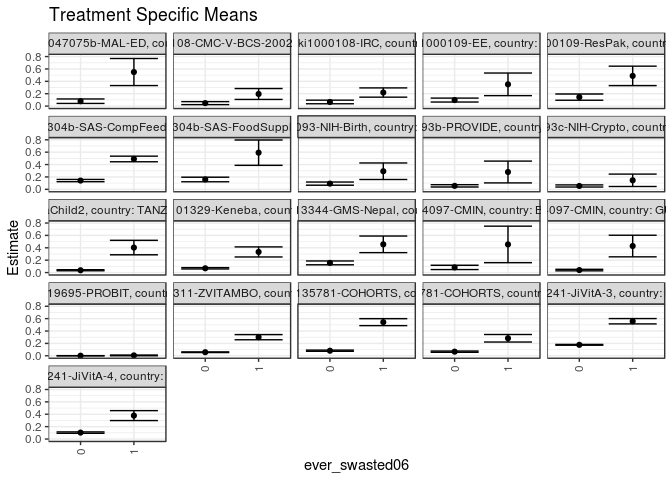

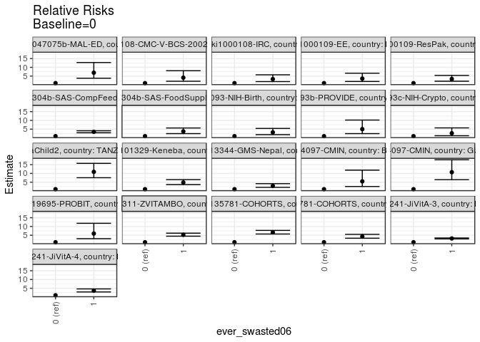

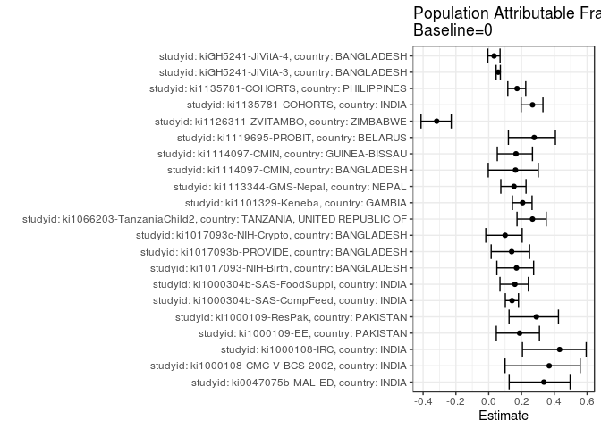

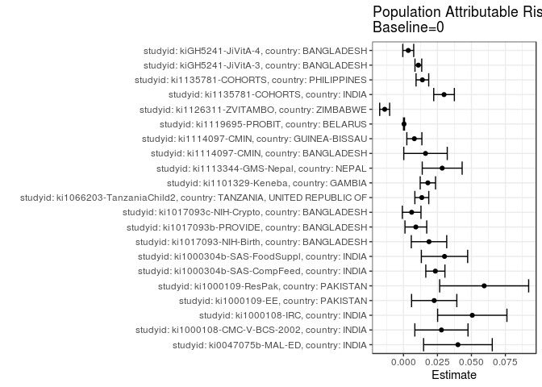

## Results Table

### Parameter: TSM

| studyid | country | intervention_level | baseline_level | estimate | ci_lower | ci_upper |
| --- | --- | --- | --- | --- | --- | --- |
| ki0047075b-MAL-ED | INDIA | 0 | NA | 0.0790698 | 0.0429227 | 0.1152169 |
| ki0047075b-MAL-ED | INDIA | 1 | NA | 0.5500000 | 0.3315024 | 0.7684976 |
| ki1000108-CMC-V-BCS-2002 | INDIA | 0 | NA | 0.0477501 | 0.0235400 | 0.0719602 |
| ki1000108-CMC-V-BCS-2002 | INDIA | 1 | NA | 0.1955300 | 0.1073318 | 0.2837282 |
| ki1000108-IRC | INDIA | 0 | NA | 0.0664365 | 0.0372391 | 0.0956339 |
| ki1000108-IRC | INDIA | 1 | NA | 0.2192306 | 0.1443330 | 0.2941281 |
| ki1000109-EE | PAKISTAN | 0 | NA | 0.0973871 | 0.0658174 | 0.1289568 |
| ki1000109-EE | PAKISTAN | 1 | NA | 0.3513486 | 0.1689888 | 0.5337084 |
| ki1000109-ResPak | PAKISTAN | 0 | NA | 0.1449568 | 0.0946732 | 0.1952405 |
| ki1000109-ResPak | PAKISTAN | 1 | NA | 0.4879264 | 0.3309364 | 0.6449164 |
| ki1000304b-SAS-CompFeed | INDIA | 0 | NA | 0.1412765 | 0.1228241 | 0.1597289 |
| ki1000304b-SAS-CompFeed | INDIA | 1 | NA | 0.4904141 | 0.4449694 | 0.5358588 |
| ki1000304b-SAS-FoodSuppl | INDIA | 0 | NA | 0.1588539 | 0.1217399 | 0.1959679 |
| ki1000304b-SAS-FoodSuppl | INDIA | 1 | NA | 0.5921495 | 0.3876067 | 0.7966923 |
| ki1017093-NIH-Birth | BANGLADESH | 0 | NA | 0.0921137 | 0.0664660 | 0.1177613 |
| ki1017093-NIH-Birth | BANGLADESH | 1 | NA | 0.2921222 | 0.1585361 | 0.4257083 |
| ki1017093b-PROVIDE | BANGLADESH | 0 | NA | 0.0559322 | 0.0373752 | 0.0744892 |
| ki1017093b-PROVIDE | BANGLADESH | 1 | NA | 0.2800000 | 0.1038524 | 0.4561476 |
| ki1017093c-NIH-Crypto | BANGLADESH | 0 | NA | 0.0542522 | 0.0372404 | 0.0712640 |
| ki1017093c-NIH-Crypto | BANGLADESH | 1 | NA | 0.1458333 | 0.0459197 | 0.2457470 |
| ki1066203-TanzaniaChild2 | TANZANIA, UNITED REPUBLIC OF | 0 | NA | 0.0370443 | 0.0286459 | 0.0454426 |
| ki1066203-TanzaniaChild2 | TANZANIA, UNITED REPUBLIC OF | 1 | NA | 0.4035983 | 0.2868470 | 0.5203496 |
| ki1101329-Keneba | GAMBIA | 0 | NA | 0.0688354 | 0.0581396 | 0.0795312 |
| ki1101329-Keneba | GAMBIA | 1 | NA | 0.3332338 | 0.2519835 | 0.4144840 |
| ki1113344-GMS-Nepal | NEPAL | 0 | NA | 0.1562542 | 0.1254224 | 0.1870860 |
| ki1113344-GMS-Nepal | NEPAL | 1 | NA | 0.4555733 | 0.3215220 | 0.5896246 |
| ki1114097-CMIN | BANGLADESH | 0 | NA | 0.0829876 | 0.0480898 | 0.1178853 |
| ki1114097-CMIN | BANGLADESH | 1 | NA | 0.4545455 | 0.1597077 | 0.7493832 |
| ki1114097-CMIN | GUINEA-BISSAU | 0 | NA | 0.0400802 | 0.0278501 | 0.0523103 |
| ki1114097-CMIN | GUINEA-BISSAU | 1 | NA | 0.4285714 | 0.2540096 | 0.6031333 |
| ki1119695-PROBIT | BELARUS | 0 | NA | 0.0010449 | 0.0002971 | 0.0017926 |
| ki1119695-PROBIT | BELARUS | 1 | NA | 0.0062354 | 0.0009301 | 0.0115407 |
| ki1126311-ZVITAMBO | ZIMBABWE | 0 | NA | 0.0574698 | 0.0525159 | 0.0624237 |
| ki1126311-ZVITAMBO | ZIMBABWE | 1 | NA | 0.3007123 | 0.2591024 | 0.3423222 |
| ki1135781-COHORTS | INDIA | 0 | NA | 0.0818623 | 0.0724608 | 0.0912638 |
| ki1135781-COHORTS | INDIA | 1 | NA | 0.5431115 | 0.4867625 | 0.5994606 |
| ki1135781-COHORTS | PHILIPPINES | 0 | NA | 0.0665635 | 0.0569787 | 0.0761483 |
| ki1135781-COHORTS | PHILIPPINES | 1 | NA | 0.2831100 | 0.2222518 | 0.3439682 |
| kiGH5241-JiVitA-3 | BANGLADESH | 0 | NA | 0.1770552 | 0.1705829 | 0.1835275 |
| kiGH5241-JiVitA-3 | BANGLADESH | 1 | NA | 0.5580604 | 0.5147434 | 0.6013775 |
| kiGH5241-JiVitA-4 | BANGLADESH | 0 | NA | 0.1037568 | 0.0928954 | 0.1146183 |
| kiGH5241-JiVitA-4 | BANGLADESH | 1 | NA | 0.3783915 | 0.2979701 | 0.4588129 |

### Parameter: E(Y)

| studyid | country | intervention_level | baseline_level | estimate | ci_lower | ci_upper |
| --- | --- | --- | --- | --- | --- | --- |
| ki0047075b-MAL-ED | INDIA | NA | NA | 0.1191489 | 0.0776405 | 0.1606574 |
| ki1000108-CMC-V-BCS-2002 | INDIA | NA | NA | 0.0756757 | 0.0486905 | 0.1026609 |
| ki1000108-IRC | INDIA | NA | NA | 0.1170732 | 0.0859146 | 0.1482317 |
| ki1000109-EE | PAKISTAN | NA | NA | 0.1200000 | 0.0870660 | 0.1529340 |
| ki1000109-ResPak | PAKISTAN | NA | NA | 0.2043478 | 0.1521230 | 0.2565727 |
| ki1000304b-SAS-CompFeed | INDIA | NA | NA | 0.1647399 | 0.1451050 | 0.1843747 |
| ki1000304b-SAS-FoodSuppl | INDIA | NA | NA | 0.1890547 | 0.1507312 | 0.2273783 |
| ki1017093-NIH-Birth | BANGLADESH | NA | NA | 0.1109057 | 0.0844206 | 0.1373909 |
| ki1017093b-PROVIDE | BANGLADESH | NA | NA | 0.0650407 | 0.0455353 | 0.0845460 |
| ki1017093c-NIH-Crypto | BANGLADESH | NA | NA | 0.0602740 | 0.0429977 | 0.0775502 |
| ki1066203-TanzaniaChild2 | TANZANIA, UNITED REPUBLIC OF | NA | NA | 0.0505451 | 0.0409848 | 0.0601054 |
| ki1101329-Keneba | GAMBIA | NA | NA | 0.0867841 | 0.0752007 | 0.0983676 |
| ki1113344-GMS-Nepal | NEPAL | NA | NA | 0.1847458 | 0.1534039 | 0.2160876 |
| ki1114097-CMIN | BANGLADESH | NA | NA | 0.0992063 | 0.0622241 | 0.1361886 |
| ki1114097-CMIN | GUINEA-BISSAU | NA | NA | 0.0480864 | 0.0349437 | 0.0612290 |
| ki1119695-PROBIT | BELARUS | NA | NA | 0.0014461 | 0.0004206 | 0.0024716 |
| ki1126311-ZVITAMBO | ZIMBABWE | NA | NA | 0.0436257 | 0.0397395 | 0.0475120 |
| ki1135781-COHORTS | INDIA | NA | NA | 0.1117237 | 0.1042858 | 0.1191617 |
| ki1135781-COHORTS | PHILIPPINES | NA | NA | 0.0804843 | 0.0704205 | 0.0905481 |
| kiGH5241-JiVitA-3 | BANGLADESH | NA | NA | 0.1880070 | 0.1814627 | 0.1945512 |
| kiGH5241-JiVitA-4 | BANGLADESH | NA | NA | 0.1072724 | 0.0967392 | 0.1178055 |

### Parameter: RR

| studyid | country | intervention_level | baseline_level | estimate | ci_lower | ci_upper |
| --- | --- | --- | --- | --- | --- | --- |
| ki0047075b-MAL-ED | INDIA | 0 | 0 | 1.000000 | 1.000000 | 1.000000 |
| ki0047075b-MAL-ED | INDIA | 1 | 0 | 6.955882 | 3.795960 | 12.746262 |
| ki1000108-CMC-V-BCS-2002 | INDIA | 0 | 0 | 1.000000 | 1.000000 | 1.000000 |
| ki1000108-CMC-V-BCS-2002 | INDIA | 1 | 0 | 4.094858 | 2.073208 | 8.087879 |
| ki1000108-IRC | INDIA | 0 | 0 | 1.000000 | 1.000000 | 1.000000 |
| ki1000108-IRC | INDIA | 1 | 0 | 3.299851 | 1.889965 | 5.761491 |
| ki1000109-EE | PAKISTAN | 0 | 0 | 1.000000 | 1.000000 | 1.000000 |
| ki1000109-EE | PAKISTAN | 1 | 0 | 3.607753 | 1.953383 | 6.663255 |
| ki1000109-ResPak | PAKISTAN | 0 | 0 | 1.000000 | 1.000000 | 1.000000 |
| ki1000109-ResPak | PAKISTAN | 1 | 0 | 3.366011 | 2.092617 | 5.414288 |
| ki1000304b-SAS-CompFeed | INDIA | 0 | 0 | 1.000000 | 1.000000 | 1.000000 |
| ki1000304b-SAS-CompFeed | INDIA | 1 | 0 | 3.471306 | 2.944999 | 4.091671 |
| ki1000304b-SAS-FoodSuppl | INDIA | 0 | 0 | 1.000000 | 1.000000 | 1.000000 |
| ki1000304b-SAS-FoodSuppl | INDIA | 1 | 0 | 3.727637 | 2.454213 | 5.661806 |
| ki1017093-NIH-Birth | BANGLADESH | 0 | 0 | 1.000000 | 1.000000 | 1.000000 |
| ki1017093-NIH-Birth | BANGLADESH | 1 | 0 | 3.171322 | 1.856736 | 5.416648 |
| ki1017093b-PROVIDE | BANGLADESH | 0 | 0 | 1.000000 | 1.000000 | 1.000000 |
| ki1017093b-PROVIDE | BANGLADESH | 1 | 0 | 5.006061 | 2.458188 | 10.194764 |
| ki1017093c-NIH-Crypto | BANGLADESH | 0 | 0 | 1.000000 | 1.000000 | 1.000000 |
| ki1017093c-NIH-Crypto | BANGLADESH | 1 | 0 | 2.688063 | 1.265352 | 5.710413 |
| ki1066203-TanzaniaChild2 | TANZANIA, UNITED REPUBLIC OF | 0 | 0 | 1.000000 | 1.000000 | 1.000000 |
| ki1066203-TanzaniaChild2 | TANZANIA, UNITED REPUBLIC OF | 1 | 0 | 10.895028 | 7.542087 | 15.738567 |
| ki1101329-Keneba | GAMBIA | 0 | 0 | 1.000000 | 1.000000 | 1.000000 |
| ki1101329-Keneba | GAMBIA | 1 | 0 | 4.841024 | 3.630286 | 6.455557 |
| ki1113344-GMS-Nepal | NEPAL | 0 | 0 | 1.000000 | 1.000000 | 1.000000 |
| ki1113344-GMS-Nepal | NEPAL | 1 | 0 | 2.915591 | 2.047450 | 4.151832 |
| ki1114097-CMIN | BANGLADESH | 0 | 0 | 1.000000 | 1.000000 | 1.000000 |
| ki1114097-CMIN | BANGLADESH | 1 | 0 | 5.477273 | 2.528380 | 11.865507 |
| ki1114097-CMIN | GUINEA-BISSAU | 0 | 0 | 1.000000 | 1.000000 | 1.000000 |
| ki1114097-CMIN | GUINEA-BISSAU | 1 | 0 | 10.692857 | 6.427866 | 17.787739 |
| ki1119695-PROBIT | BELARUS | 0 | 0 | 1.000000 | 1.000000 | 1.000000 |
| ki1119695-PROBIT | BELARUS | 1 | 0 | 5.967654 | 3.017791 | 11.800979 |
| ki1126311-ZVITAMBO | ZIMBABWE | 0 | 0 | 1.000000 | 1.000000 | 1.000000 |
| ki1126311-ZVITAMBO | ZIMBABWE | 1 | 0 | 5.232526 | 4.443477 | 6.161689 |
| ki1135781-COHORTS | INDIA | 0 | 0 | 1.000000 | 1.000000 | 1.000000 |
| ki1135781-COHORTS | INDIA | 1 | 0 | 6.634451 | 5.685436 | 7.741875 |
| ki1135781-COHORTS | PHILIPPINES | 0 | 0 | 1.000000 | 1.000000 | 1.000000 |
| ki1135781-COHORTS | PHILIPPINES | 1 | 0 | 4.253234 | 3.287976 | 5.501863 |
| kiGH5241-JiVitA-3 | BANGLADESH | 0 | 0 | 1.000000 | 1.000000 | 1.000000 |
| kiGH5241-JiVitA-3 | BANGLADESH | 1 | 0 | 3.151901 | 2.898433 | 3.427535 |
| kiGH5241-JiVitA-4 | BANGLADESH | 0 | 0 | 1.000000 | 1.000000 | 1.000000 |
| kiGH5241-JiVitA-4 | BANGLADESH | 1 | 0 | 3.646907 | 2.880930 | 4.616542 |

### Parameter: PAR

| studyid | country | intervention_level | baseline_level | estimate | ci_lower | ci_upper |
| --- | --- | --- | --- | --- | --- | --- |
| ki0047075b-MAL-ED | INDIA | 0 | NA | 0.0400792 | 0.0148059 | 0.0653525 |
| ki1000108-CMC-V-BCS-2002 | INDIA | 0 | NA | 0.0279256 | 0.0083601 | 0.0474910 |
| ki1000108-IRC | INDIA | 0 | NA | 0.0506367 | 0.0251279 | 0.0761455 |
| ki1000109-EE | PAKISTAN | 0 | NA | 0.0226129 | 0.0059566 | 0.0392693 |
| ki1000109-ResPak | PAKISTAN | 0 | NA | 0.0593910 | 0.0266453 | 0.0921367 |
| ki1000304b-SAS-CompFeed | INDIA | 0 | NA | 0.0234634 | 0.0164283 | 0.0304984 |
| ki1000304b-SAS-FoodSuppl | INDIA | 0 | NA | 0.0302009 | 0.0131640 | 0.0472377 |
| ki1017093-NIH-Birth | BANGLADESH | 0 | NA | 0.0187920 | 0.0057606 | 0.0318235 |
| ki1017093b-PROVIDE | BANGLADESH | 0 | NA | 0.0091084 | 0.0011028 | 0.0171141 |
| ki1017093c-NIH-Crypto | BANGLADESH | 0 | NA | 0.0060218 | -0.0008431 | 0.0128867 |
| ki1066203-TanzaniaChild2 | TANZANIA, UNITED REPUBLIC OF | 0 | NA | 0.0135008 | 0.0083871 | 0.0186146 |
| ki1101329-Keneba | GAMBIA | 0 | NA | 0.0179488 | 0.0123019 | 0.0235956 |
| ki1113344-GMS-Nepal | NEPAL | 0 | NA | 0.0284916 | 0.0138072 | 0.0431759 |
| ki1114097-CMIN | BANGLADESH | 0 | NA | 0.0162188 | 0.0002139 | 0.0322237 |
| ki1114097-CMIN | GUINEA-BISSAU | 0 | NA | 0.0080062 | 0.0024714 | 0.0135410 |
| ki1119695-PROBIT | BELARUS | 0 | NA | 0.0004013 | 0.0000329 | 0.0007697 |
| ki1126311-ZVITAMBO | ZIMBABWE | 0 | NA | -0.0138441 | -0.0175024 | -0.0101858 |
| ki1135781-COHORTS | INDIA | 0 | NA | 0.0298614 | 0.0222590 | 0.0374638 |
| ki1135781-COHORTS | PHILIPPINES | 0 | NA | 0.0139209 | 0.0092644 | 0.0185773 |
| kiGH5241-JiVitA-3 | BANGLADESH | 0 | NA | 0.0109518 | 0.0084687 | 0.0134349 |
| kiGH5241-JiVitA-4 | BANGLADESH | 0 | NA | 0.0035156 | -0.0005043 | 0.0075354 |

### Parameter: PAF

| studyid | country | intervention_level | baseline_level | estimate | ci_lower | ci_upper |
| --- | --- | --- | --- | --- | --- | --- |
| ki0047075b-MAL-ED | INDIA | 0 | NA | 0.3363787 | 0.1248069 | 0.4968046 |
| ki1000108-CMC-V-BCS-2002 | INDIA | 0 | NA | 0.3690162 | 0.0995844 | 0.5578259 |
| ki1000108-IRC | INDIA | 0 | NA | 0.4325215 | 0.2055351 | 0.5946556 |
| ki1000109-EE | PAKISTAN | 0 | NA | 0.1884410 | 0.0462855 | 0.3094076 |
| ki1000109-ResPak | PAKISTAN | 0 | NA | 0.2906367 | 0.1242267 | 0.4254263 |
| ki1000304b-SAS-CompFeed | INDIA | 0 | NA | 0.1424267 | 0.1012739 | 0.1816951 |
| ki1000304b-SAS-FoodSuppl | INDIA | 0 | NA | 0.1597467 | 0.0687519 | 0.2418501 |
| ki1017093-NIH-Birth | BANGLADESH | 0 | NA | 0.1694416 | 0.0497492 | 0.2740577 |
| ki1017093b-PROVIDE | BANGLADESH | 0 | NA | 0.1400424 | 0.0151570 | 0.2490913 |
| ki1017093c-NIH-Crypto | BANGLADESH | 0 | NA | 0.0999067 | -0.0178485 | 0.2040388 |
| ki1066203-TanzaniaChild2 | TANZANIA, UNITED REPUBLIC OF | 0 | NA | 0.2671047 | 0.1727828 | 0.3506717 |
| ki1101329-Keneba | GAMBIA | 0 | NA | 0.2068208 | 0.1446991 | 0.2644305 |
| ki1113344-GMS-Nepal | NEPAL | 0 | NA | 0.1542204 | 0.0739225 | 0.2275559 |
| ki1114097-CMIN | BANGLADESH | 0 | NA | 0.1634855 | -0.0027793 | 0.3021829 |
| ki1114097-CMIN | GUINEA-BISSAU | 0 | NA | 0.1664963 | 0.0523415 | 0.2669000 |
| ki1119695-PROBIT | BELARUS | 0 | NA | 0.2774767 | 0.1201276 | 0.4066867 |
| ki1126311-ZVITAMBO | ZIMBABWE | 0 | NA | -0.3173373 | -0.4127701 | -0.2283511 |
| ki1135781-COHORTS | INDIA | 0 | NA | 0.2672791 | 0.1977081 | 0.3308172 |
| ki1135781-COHORTS | PHILIPPINES | 0 | NA | 0.1729636 | 0.1164865 | 0.2258306 |
| kiGH5241-JiVitA-3 | BANGLADESH | 0 | NA | 0.0582520 | 0.0452460 | 0.0710807 |
| kiGH5241-JiVitA-4 | BANGLADESH | 0 | NA | 0.0327723 | -0.0052186 | 0.0693275 |